# data-procesesing

Ahora veamos como se graficamente la distribución de los siniestros:

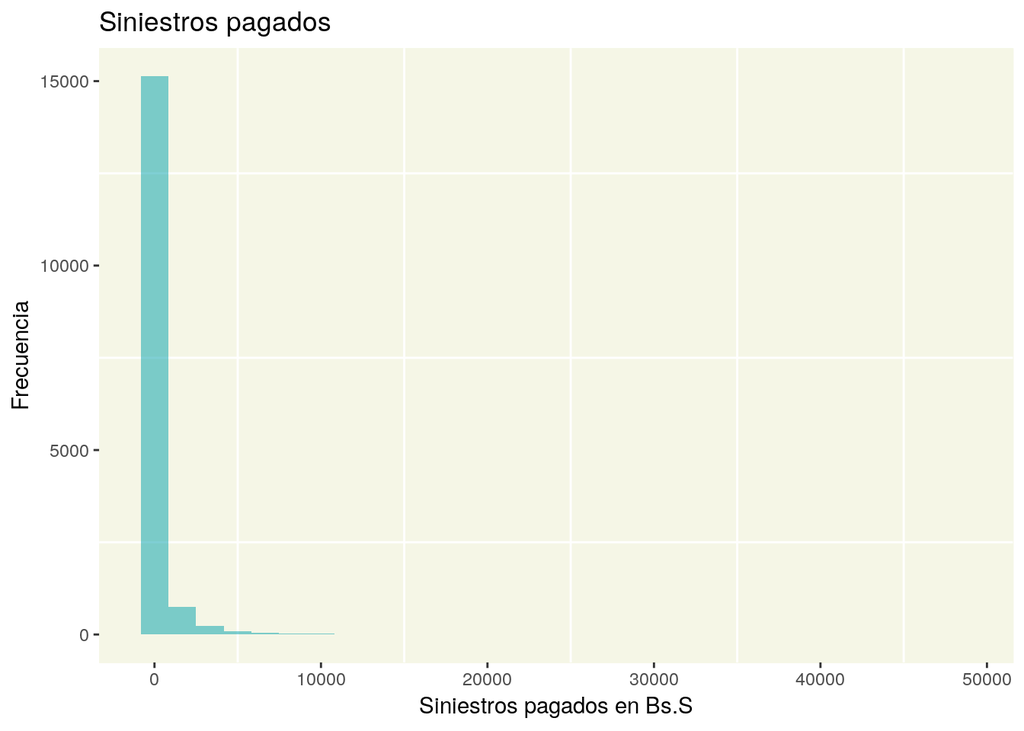

```r
siniestros  %>%
ggplot(aes(x = pagado)) +
    geom_histogram(position="identity",
                   fill = "#019FAA",
                   alpha = 0.5
                   ) +
  labs(title = "Siniestros pagados", x = "Siniestros pagados en Bs.S",
                   y = "Frecuencia") +
  theme(
    panel.background = element_rect(fill = "#F5F6E6",
                                colour = "#F5F6E6",
                                size = 0.5, linetype = "solid"),
    panel.grid.major = element_blank(),
    panel.grid.minor = element_line(size = 0.5,
                                    linetype = 'solid',
                                    colour = "white")
  )
```

En los siniestros vemos un comportamiento similiar a las sumas aseguradas por la inflación, por lo que debemos realizar un ajuste por inflación a los datos.

Dado a que no se manejan cifras oficiales del Índice de Precios al Consumidor (IPC) para los años 2017 y 2018, usaremos la variación mensual del monto promedio de los siniestros como un indicador de inflación.

```r
inflacion <- siniestros %>%
  select (emisionid, pagado) %>%
  mutate(año = year(emisionid), mes = month(emisionid)) %>%
  group_by(año,mes) %>%
  summarize(media = mean(pagado, na.rm = TRUE)) %>%
  arrange(año, mes) %>%
  ungroup() %>%
  mutate(var = media / lag(media) -1,
         cum_var = media/first(media)-1
         )
knitr::kable(inflacion)
```

| año | mes | media | var | cum_var |
| --- | --- | --- | --- | --- |
| 2017 | 9 | 23.41679 | NA | 0.0000000 |
| 2017 | 10 | 27.01193 | 0.1535287 | 0.1535287 |
| 2017 | 11 | 55.90160 | 1.0695149 | 1.3872448 |
| 2017 | 12 | 96.78060 | 0.7312672 | 3.1329585 |
| 2018 | 1 | 138.37714 | 0.4298024 | 4.9093142 |
| 2018 | 2 | 215.42164 | 0.5567718 | 8.1994538 |
| 2018 | 3 | 293.16006 | 0.3608664 | 11.5192271 |
| 2018 | 4 | 541.61836 | 0.8475176 | 22.1294919 |
| 2018 | 5 | 1030.43471 | 0.9025107 | 43.0041055 |
| 2018 | 6 | 1865.34396 | 0.8102495 | 78.6584120 |
| 2018 | 7 | 2814.30078 | 0.5087302 | 119.1830523 |
| 2018 | 8 | 3448.78105 | 0.2254486 | 146.2781572 |

Seleccionaremos para nuestros calculos solo aquellas pólizas emitidas entre las fechas del primero de septiembre de 2017 y el 31 de agosto de 2018.

```r
asegurados <- asegurados %>% filter(fechadesde >='2017-09-01' & fechadesde < '2018-09-01')
```

```r
asegurados <-
asegurados %>%
  mutate(año = year(fechadesde), mes = month(fechadesde))  %>%
  inner_join(inflacion %>%
               select(año, mes, cum_var),
             by = c('año','mes')
             ) %>%
  mutate(valor_actual_sumaseg= sumaseg * (1 + cum_var))
```